# Unit 8 Linear Models: In Class Discussion

## Multiple regression

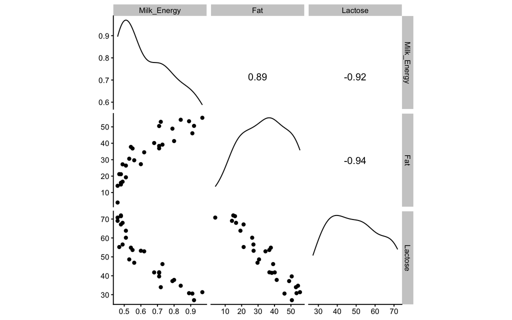

## Multiple regression

```r
fm <- lm(Milk_Energy ~ Fat + Lactose, data = M)
summary(fm)
```

```
##
## Call:
## lm(formula = Milk_Energy ~ Fat + Lactose, data = M)
##
## Residuals:
##      Min       1Q   Median       3Q      Max
## -0.11350 -0.05047  0.01103  0.04649  0.12701
##
## Coefficients:
##              Estimate Std. Error t value Pr(>|t|)
## (Intercept)  1.007372   0.211168   4.770 6.16e-05 ***
## Fat          0.001952   0.002533   0.771  0.44784
## Lactose     -0.008709   0.002575  -3.382  0.00229 **
## ---
## Signif. codes:  0 '***' 0.001 '**' 0.01 '*' 0.05 '.' 0.1 ' ' 1
##
## Residual standard error: 0.06447 on 26 degrees of freedom
## Multiple R-squared:  0.8518, Adjusted R-squared:  0.8404
## F-statistic: 74.74 on 2 and 26 DF,  p-value: 1.657e-11
```

## Relationships between variables

[figure not shown]

What is the independent contribution of X1 to Y?

How much variation does X1 alone explain in Y?

## Estimate `Fat` coefficient

1. Use `Lactose` to predict `Fat`, which will take the effect of `Lactose` out of the model when we predict `Milk_Energy`
2. Extract the residuals and add them onto the data.

```r
fm_Lact <- lm(Fat ~ Lactose, data = M)
M$resid_Lact <- residuals(fm_Lact)
M |> arrange(resid_Lact) |> slice(1:5)
```

```
## # A tibble: 5 × 5
##   Species             Milk_Energy   Fat Lactose resid_Lact
##   <chr>                     <dbl> <dbl>   <dbl>      <dbl>
## 1 Callimico goeldii          0.46  3.93    70.8      -9.80
## 2 Alouatta seniculus         0.47 21.2     55.2      -7.42
## 3 A palliata                 0.56 29.7     46.9      -6.94
## 4 Saimiri boliviensis        0.91 46.1     30.6      -6.12
## 5 S sciureus                 0.92 50.6     27.1      -4.96
```

## Estimate `Fat` coefficient

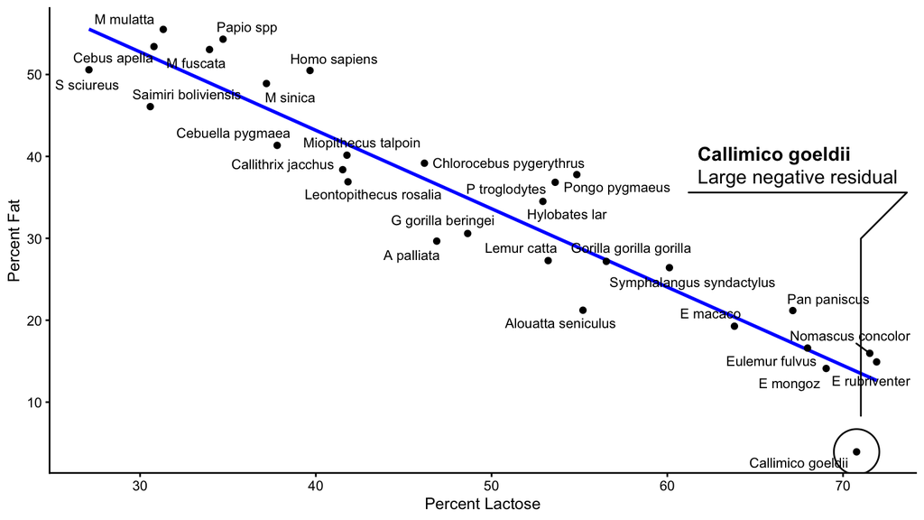

## Estimate `Fat` coefficient

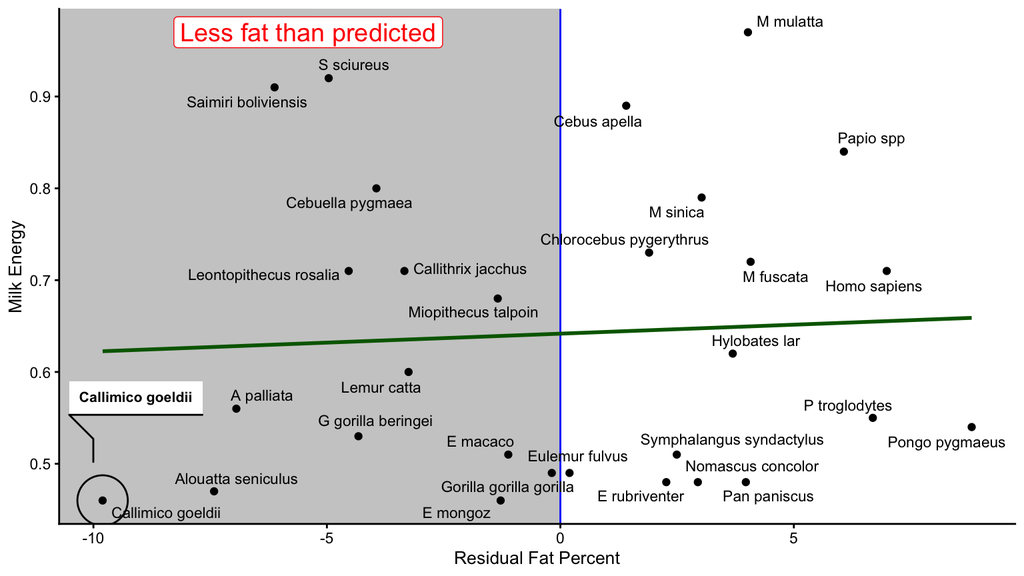

## Estimate `Fat` coefficient

```r
coef(lm(Milk_Energy ~ resid_Lact, data = M))
```

```
## (Intercept)  resid_Lact
## 0.641724138 0.001952441
```

```r
coef(fm)
```

```
##  (Intercept)          Fat      Lactose
##  1.007371840  0.001952441 -0.008708827
```

## Estimate `Lactose` coefficient

1. Use `Fat` to predict `Lactose`, which will take the effect of `Fat` out of the model when we predict `Milk_Energy`
2. Extract the residuals and add them onto the data.frame `M`.

```r
fm_Fat <- lm(Lactose ~ Fat, data = M)
M$resid_Fat <- residuals(fm_Fat)
```

## Estimate `Lactose` coefficient

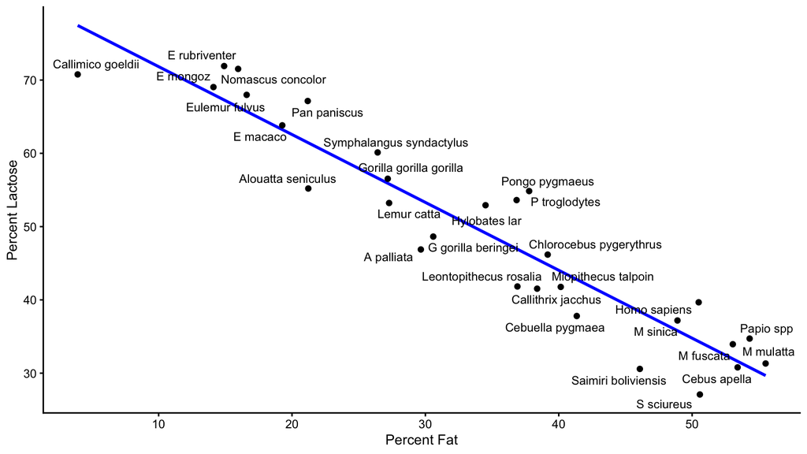

## Estimate `Lactose` coefficient

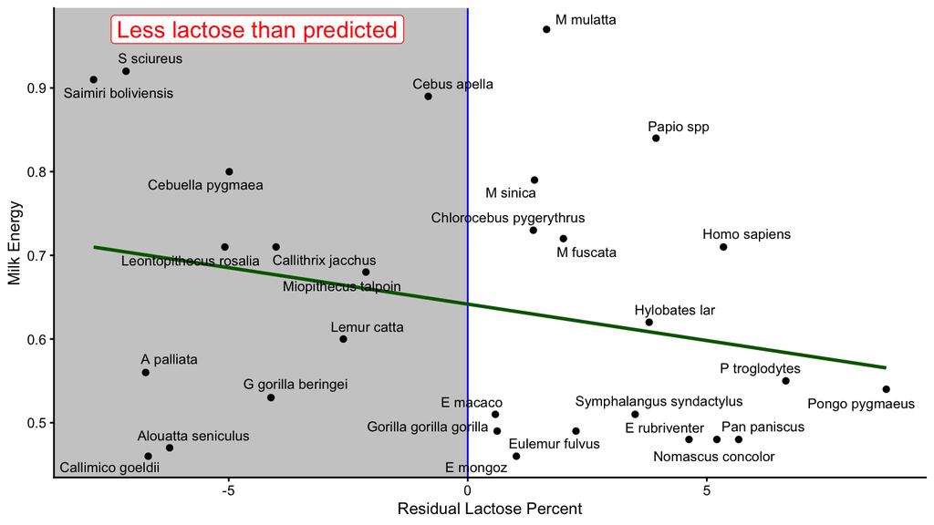

## Estimate `Lactose` coefficient

```r
coef(lm(Milk_Energy ~ resid_Fat, data = M))
```

```
##  (Intercept)    resid_Fat
##  0.641724138 -0.008708827
```

```r
coef(fm)
```

```
##  (Intercept)          Fat      Lactose
##  1.007371840  0.001952441 -0.008708827
```

## Compare

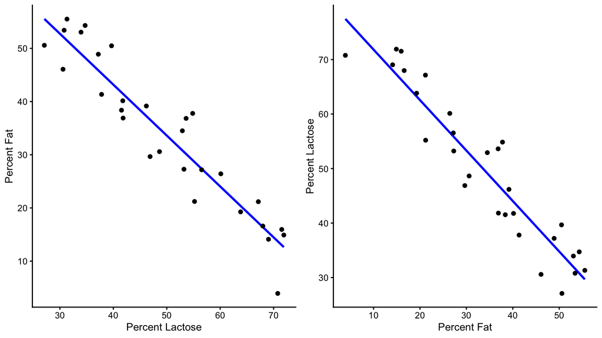

## Compare

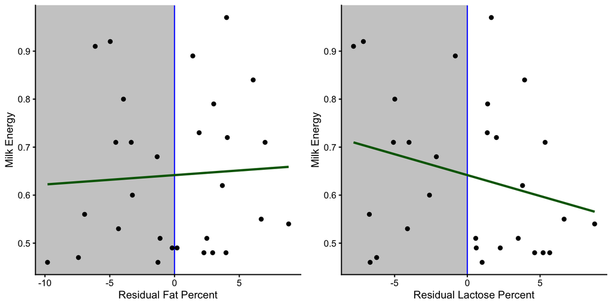

```
##  (Intercept)          Fat      Lactose
##  1.007371840  0.001952441 -0.008708827
```

## Relationshps between variables

[figure not shown]

What is the independent contribution of X1 to Y?

How much variation does X1 alone explain in Y?

*Experimental control*

- Eliminate variation in Y due to X2
- For continuous variables, if X2 sampled randomly – same in both groups
- For categorical variables, if you have a balanced design

## Statistical control

\[\frac{Variation~in~Y~explained~by~X1}{Total~Variation~in~Y}\]

What regression does:

[figure not shown]

If X1 and X2 are uncorrelated:

- Y ~ X1 *and*
- Y ~ X1 + X2

will give the same coefficient for X1.

With categorical variables, a balanced design produced uncorrelated (orthogonal) Xs.

## Statistical control

| SoilType | LightLevel |
| --- | --- |
| 1 | 1 |
| 1 | 1 |
| 1 | 1 |
| 1 | 0 |
| 1 | 0 |
| 1 | 0 |

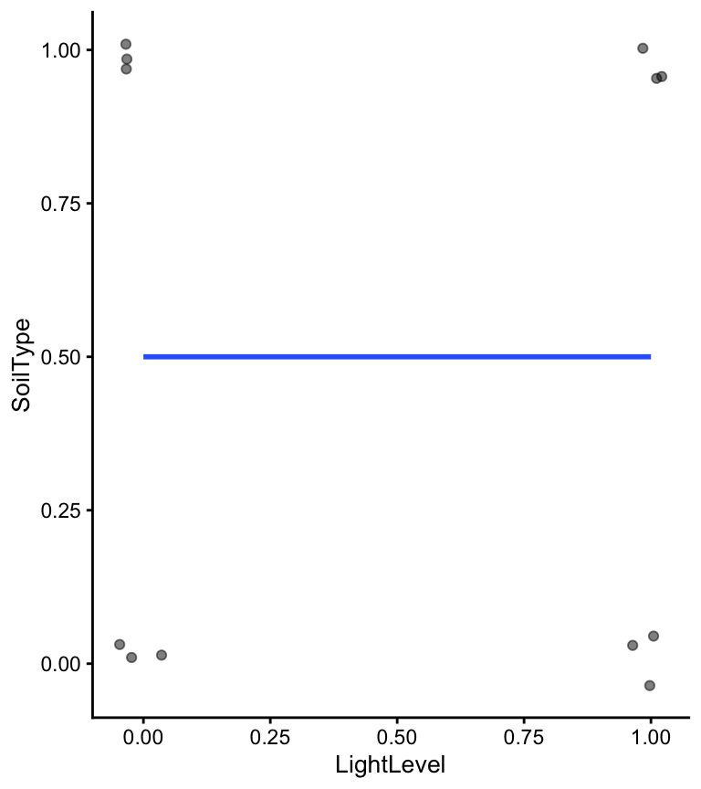

## Statistical control

| SoilType | LightLevel |
| --- | --- |
| 0 | 0 |
| 0 | 0 |
| 0 | 0 |
| 1 | 1 |
| 1 | 1 |
| 1 | 1 |

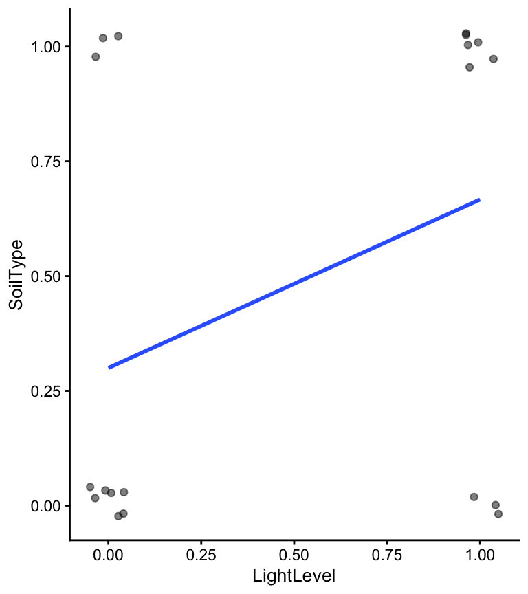

## Statistical control

\[\frac{Variation~in~Y~explained~by~X1}{Variation~not~explained~by~X2}\]

Another method:

[figure not shown]

1. Perform:
   - Y ~ X2
2. Get residuals
3. Perform:
   - Residuals ~ X1

## Want to know more?

- Tabachnick and Fidell (2001)
- Search terms: Partial vs. Semi-partial Correlation